# ISLR Lab 5

## Labs 5.3.1, 5.3.2, 5.3.3

### Lab 5.3.1: Validation Set Approach

```r
library(ISLR)
library(tidyverse)
library(dplyr)
set.seed(69)
colnames(Auto)
```

```
[1] "mpg"          "cylinders"    "displacement"
[4] "horsepower"   "weight"       "acceleration"
[7] "year"         "origin"       "name"
```

```r
#attach(Auto)
train <- sample(392, 196)
#train
```

Now we take that subset of data and fit a linear regression model

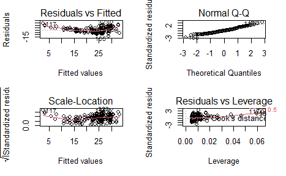

```r
lm.fit.auto <- lm(mpg~horsepower, data = Auto, subset = train)
par(mfrow=c(2,2))
plot(lm.fit)
```

```r
summary(lm.fit)
```

[output not shown]

We now use the predict() function to estimate the response for all 392 observations, and we use the mean() function to calculate the MSE of the 196 observations in the validation set. Note that the -train index below selects only the observations that are not in the training set.

```r
attach(Auto)
mean((mpg-predict(lm.fit, Auto))[-train]^2)
```

```
[1] 21.69524
```

We can use poly to estimate the test error for quadratic and cubic regressions

```r
lm.fit2 <- lm(mpg~poly(horsepower, 2), data = Auto, subset = train)
mean((mpg-predict(lm.fit2, Auto))[-train]^2)
```

```
[1] 17.49556
```

```r
lm.fit3 <- lm(mpg~poly(horsepower, 3), data=Auto, subset=train)
mean((mpg-predict(lm.fit3, Auto))[-train]^2)
```

```
[1] 17.61054
```

### Lab 5.3.2: Leave One Out Cross Validation

The glm() function to perform logistic regression by passing in the family=“binomial” argument. But if we use glm() to fit a model without passing in the family argument, then it performs linear regression, just like the lm() function

```r
summary(glm.fit)
```

[output not shown]

Let’s check if they are both the same

```r
lm.fit <- lm(mpg~horsepower, data=Auto)
summary(lm.fit)
```

```
Call:
lm(formula = mpg ~ horsepower, data = Auto)

Residuals:
     Min       1Q   Median       3Q      Max
-13.5710  -3.2592  -0.3435   2.7630  16.9240

Coefficients:
             Estimate Std. Error t value Pr(>|t|)
(Intercept) 39.935861   0.717499   55.66   <2e-16 ***
horsepower  -0.157845   0.006446  -24.49   <2e-16 ***
---
Signif. codes:
0 ‘***’ 0.001 ‘**’ 0.01 ‘*’ 0.05 ‘.’ 0.1 ‘ ’ 1

Residual standard error: 4.906 on 390 degrees of freedom
Multiple R-squared:  0.6059,    Adjusted R-squared:  0.6049
F-statistic: 599.7 on 1 and 390 DF,  p-value: < 2.2e-16
```

They are the same! The glm() function can be used with cv.glm() The two numbers in the delta vector contain the cross-validation results.

```r
library(boot)
glm.fit <- glm(mpg~horsepower, data=Auto)

cv.err <- cv.glm(Auto, glm.fit)
cv.err$delta
```

```
[1] 24.23151 24.23114
```

We can automate the process for increasingly complex polynomials

```r
cv.error <- rep(0,5)
for(i in 1:5)
{
  glm.fit <- glm(mpg~poly(horsepower, i), data=Auto)
  cv.error[i] <- cv.glm(Auto, glm.fit)$delta[1]
}
cv.error
```

```
[1] 24.23151 19.24821 19.33498 19.42443 19.03321
```

### Lab 5.3.3: K-fold cross validation

```r
set.seed(42)
cv.error.10 = rep(0,10)
for(i in 1:10)
{
  glm.fit <- glm(mpg~poly(horsepower, i), data=Boston)
  cv.error.10[i] <- cv.glm(Auto, glm.fit, K=10)$delta[1]
}
cv.error.10
```

[output not shown]